# Blackwell - Brand Preference

## 5.2 Random Forest

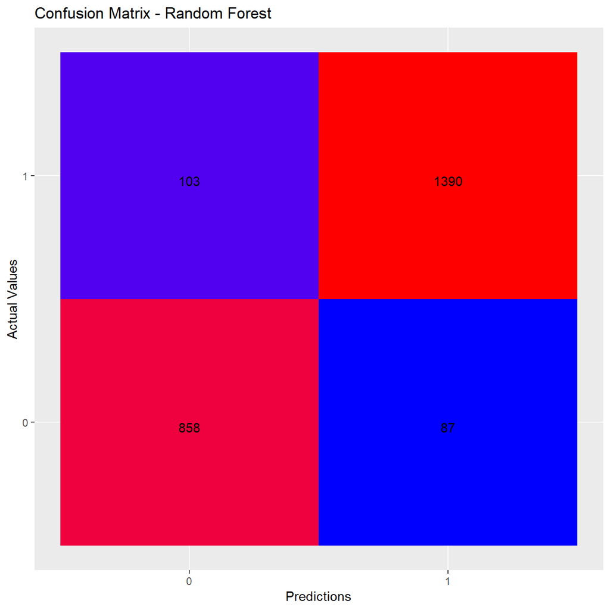

```r
library(parallel)
library(doParallel)

#calculate number of cores
no_cores <- detectCores() - 1

#initiate cluster
cl<- makeCluster(no_cores)
registerDoParallel(cl)


trainSize <- createDataPartition(y = new$brand, p = 0.75, list = FALSE)
training <- new[trainSize,]
test <- new[-trainSize,]


rf <- train(brand~ ., method = "rf",
            data = training,
            trControl = trainControl(method = "cv", number = 5),
            prox = TRUE, allowParallel = TRUE)

test_pred <- predict(rf,  newdata = test)


stopCluster(cl)
registerDoSEQ()


#plotting down the confusion matrix
confusion_matrix <- as.data.frame(table(test_pred, test$brand))

d <- ggplot(data = confusion_matrix,
       mapping = aes(x = test_pred,
                     y = confusion_matrix$Var2)) +
      geom_tile(aes(fill = Freq)) +
      geom_text(aes(label = sprintf("%1.0f", Freq)), vjust = 1) +
      scale_fill_gradient(low = "blue",
                      high = "red",
                      trans = "log") +
      labs( title = "Confusion Matrix - Random Forest", x = "Predictions", y = "Actual Values") +
      theme(legend.position = "none")
d
```

## 5.3 GBM & SVM - Machine learning bench

In order to choose the best model for this task, SVM and GBM were tested as well. Below is a summary of how well they performed in terms of accuracy and randomness.

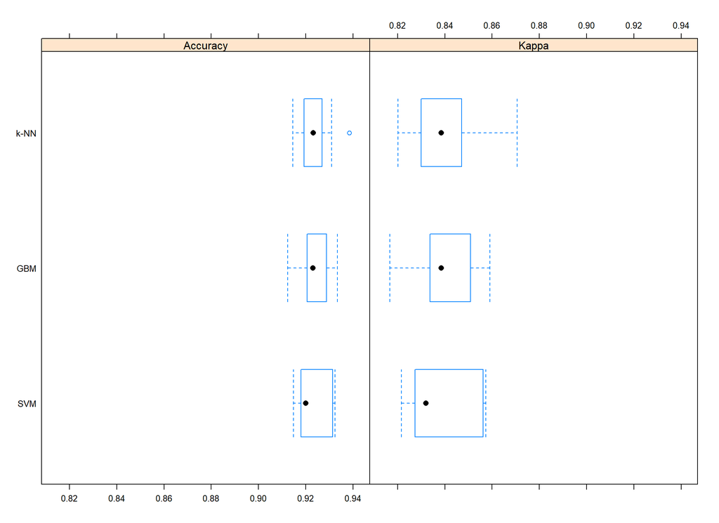

```r
library(mlbench)

# train the GBM model
set.seed(100)
modelGbm <- train(brand~ salary + age, data= new, method="gbm", trControl= trctrl, verbose=FALSE, preProcess= c("center", "scale"),
                  tuneLength = 10)
# train the SVM model
set.seed(100)
modelSvm <- train(brand~ salary + age, data= new, method="svmRadial", trControl= trctrl, preProcess= c("center", "scale"),
                  tuneLength = 10)
# collect resamples
results <- resamples(list("k-NN"= knn_fit, GBM=modelGbm, SVM=modelSvm))
# boxplots of results
bwplot(results)
```

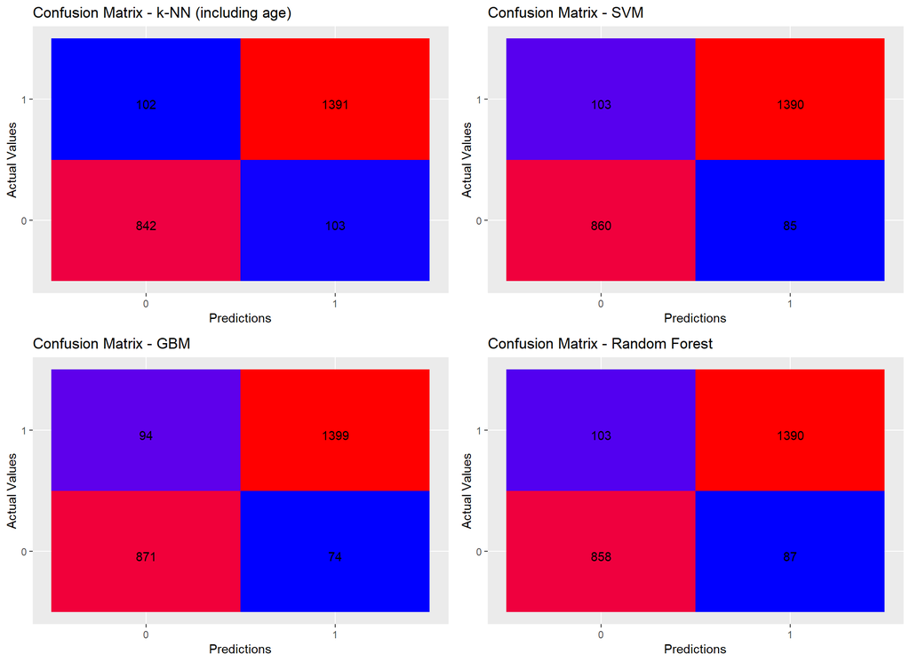

```r
test_pred <- predict(modelSvm,  newdata = test)
confusion_matrix <- as.data.frame(table(test_pred, test$brand))

#confusion matrix for svm
s <- ggplot(data = confusion_matrix,
       mapping = aes(x = test_pred,
                     y = confusion_matrix$Var2)) +
      geom_tile(aes(fill = Freq)) +
      geom_text(aes(label = sprintf("%1.0f", Freq)), vjust = 1) +
      scale_fill_gradient(low = "blue",
                      high = "red",
                      trans = "log") +
      labs( title = "Confusion Matrix - SVM", x = "Predictions", y = "Actual Values") +
      theme(legend.position = "none")


#confusion matrix for gbm
test_pred <- predict(modelGbm,  newdata = test)
confusion_matrix <- as.data.frame(table(test_pred, test$brand))




g <- ggplot(data = confusion_matrix,
       mapping = aes(x = test_pred,
                     y = confusion_matrix$Var2)) +
      geom_tile(aes(fill = Freq)) +
      geom_text(aes(label = sprintf("%1.0f", Freq)), vjust = 1) +
      scale_fill_gradient(low = "blue",
                      high = "red",
                      trans = "log") +
      labs( title = "Confusion Matrix - GBM", x = "Predictions", y = "Actual Values") +
      theme(legend.position = "none")


grid.arrange(u, s, g, d)
```

# 6 Predictions

The graph below shows how the brand preferences are distributed. Similar to the Complete Survey, 38% of the customers chose *Acer* and the rest chose *Sony*.

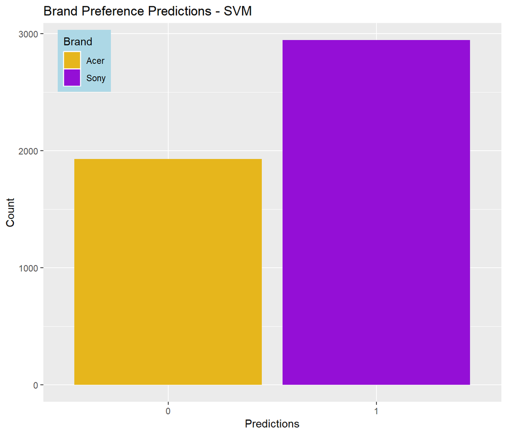

```r
pred <- predict(modelSvm,  newdata = new_thedata)

f <- ggplot(new_thedata, aes(pred, fill = pred)) +
  geom_histogram(stat = "count") +
  labs(title = "Brand Preference Predictions - SVM", x = "Predictions", y = "Count") +
  scale_fill_manual(labels = c("Acer", "Sony"), values = c("#E6B61C", "#940FD6")) +
  guides(fill = guide_legend(title = "Brand")) +
  theme(legend.position = c(0.09, 0.9), legend.background = element_rect("lightblue"))

f
```

# 7 Conclusion

The findings from this report have a high confidence level of accuracy and reliability for taking action in the future. By maximizing the True Positives it would help the sales and marketing team to focus their commercial efforts and reduce costs(time & budget). Beside smoothing internal operations this would also allow Blackwell to pursue deeper and more meaningful customer relationships which would increase a customer’s lifetime value for the company and increase profits in the long run. Future recommendations for better brand predictions would include: a higher number of surveyed people and a more extensive list of attributes to profile customers even better.